# ST 558 Project 2

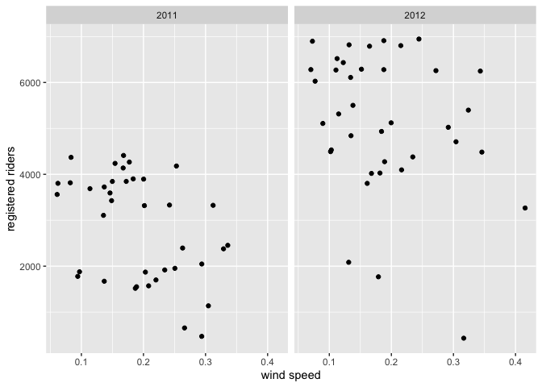

```r
g + geom_point(aes(x = windspeed, y = registered)) + facet_wrap(~ yr) +
  labs(x = "wind speed", y = "registered riders")
```

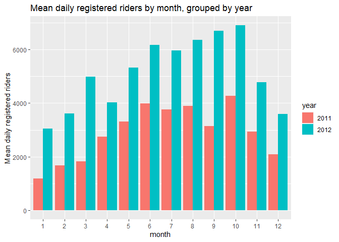

```r
g2 <- ggplot(meanByMonthYr, aes(x = mnth))
g2 + geom_bar(aes(y = meanReg, fill = yr), position = "dodge", stat = "identity") +
  labs(title = "Mean daily registered riders by month, grouped by year", x = "month", y = "Mean daily registered riders", fill = "year")
```

We will look next in more detail at the relationship between quantitative weather variables and the `registered` response variable. The appearance of nonlinear relationships in the scatter plots below may indicate the need for quadratic terms in our linear regression models. The adjusted temperature variable, `atemp`, seems particularly likely to require a quadratic term, as both low and high temperatures can discourage people from bicycling. Similarly, with humidity and windspeed, low to moderate values may have no effect, but particularly high values could have an effect, so those variables may also require quadratic terms.

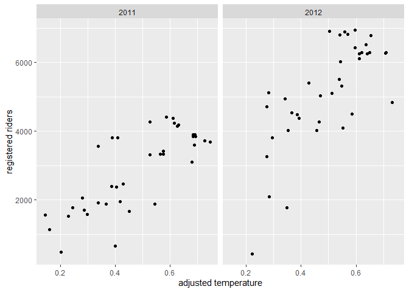

```r
g + geom_point(aes(x = atemp, y = registered)) + facet_wrap(~ yr) +
  labs(x = "adjusted temperature", y = "registered riders")
```

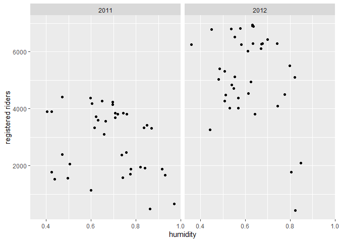

```r
g + geom_point(aes(x = hum, y = registered)) + facet_wrap(~ yr) +
  labs(x = "humidity", y = "registered riders")
```

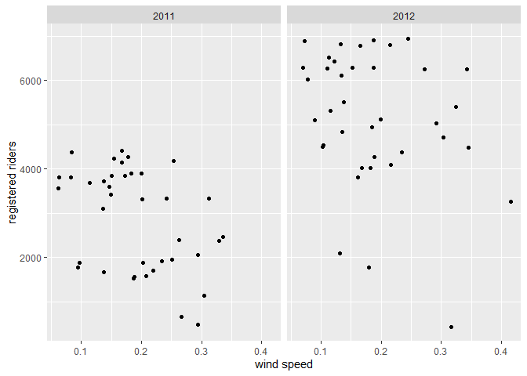

```r
g + geom_point(aes(x = windspeed, y = registered)) + facet_wrap(~ yr) +
  labs(x = "wind speed", y = "registered riders")
```

We now view a table displaying the mean number of `registered`, `casual`, and total riders at each level of the categorical `weathersit` variable. It seems plausible that in rain or snow, the number of casual riders might decrease by a larger factor than would the number of registered riders.

```r
meanByWeather <- dayTrain %>% group_by(weathersit) %>%
  summarize(meanCas = mean(casual), meanReg = mean(registered), meanTotal = mean(cnt))
kable(meanByWeather, digits = 1, col.names = c("Weather", "Mean Casual Riders", "Mean Registered Riders", "Mean Total Riders"), caption = "Average # of riders by weather category")
```

| Weather | Mean Casual Riders | Mean Registered Riders | Mean Total Riders |
| --- | --- | --- | --- |
| mist | 408.0 | 3218.2 | 3626.2 |
| clear | 694.6 | 4659.9 | 5354.4 |
| lightRainOrSnow | 71.2 | 1021.8 | 1093.0 |

Average # of riders by weather category

```r
scatter_james <- ggplot(data=dayTrain, aes(x=temp, y=registered)) +
                 geom_point(aes(color=weathersit))
hist_james <- ggplot(data=dayTrain, aes(x=weathersit)) +
              geom_histogram(stat='count', aes(fill=workingday)) +
              ggtitle('Frequency of Weather') +
              xlab('Weather Type') + ylab('Count')

bar_james <- ggplot(data=dayTrain %>%
                 select(season, casual, registered) %>%
                 pivot_longer(cols=c(casual, registered),
                              names_to = 'metrics',
                              values_to = 'riders') %>%
                 group_by(season, metrics) %>%
                 summarise(avg_riders = mean(riders)),
            aes(x=season, y=avg_riders, fill=metrics)) +
            geom_bar(stat='identity', position='dodge') +
            ggtitle('Average Number of Riders') +
              xlab('Season') + ylab('Average # of Riders')

box_james <- ggplot(data=dayTrain, aes(x=mnth, y=temp)) +
             geom_boxplot(aes(color=season))
```

Looking at the bar graph below, in all seasons the registered user base far out-performs the casual base. This further confirms our plan of analyzing the registered group as the priority.

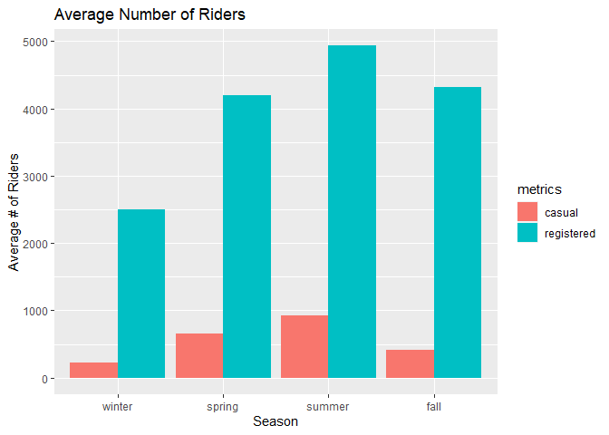

Since we don’t have a domain expert, we need to try to figure out what variables are important and which we could exclude. We already know that the two temperature variables have near perfect correlation, and clearly date is redundant with mnth and yr. I would think season is as well covered by mnth.

That leaves temperature, weather, and the working day flag as the most likely to be relevant parameters. Looking at the plots below, I think we can make a few obvious inferences:

- looking at the scatter plot on the left, we can see that as the temperature goes up, the number of riders also goes up - at least up to a point. And even in the highest temperatures, ridership is way up over lowest temperatures.
- the middle figure displays that temperature is highest in spring, summer, and early fall
- looking at the figure on the right, there are very few days of extremely poor weather. Most days are clear, which are the best days for ridership.

[figure not shown]

```r
summ_james <- dayTrain %>% rename(total = cnt) %>%
              pivot_longer(cols=c(casual, registered, total),
                           names_to = 'metrics',
                           values_to = 'riders') %>%
              group_by(metrics) %>%
              summarise(min = min(riders),
                        lower25 = quantile(riders, 0.25),
                        median = median(riders),
                        mean = mean(riders),
                        upper75 = quantile(riders, 0.75),
                        max = max(riders))  %>%
              pivot_longer(cols=c(min, lower25, median,
                                  mean, upper75, max),
                           names_to = 'Summary',
                           values_to = 'stats') %>%
              pivot_wider(names_from = metrics, values_from = stats)

kable(summ_james, digits=0)
```

[figure not shown]

```r
summ_james <- dayTrain %>% rename(total = cnt) %>%
              pivot_longer(cols=c(casual, registered, total),
                           names_to = 'metrics',
                           values_to = 'riders') %>%
              group_by(metrics) %>%
              summarise(min = min(riders),
                        lower25 = quantile(riders, 0.25),
                        median = median(riders),
                        mean = mean(riders),
                        upper75 = quantile(riders, 0.75),
                        max = max(riders))  %>%
              pivot_longer(cols=c(min, lower25, median,
                                  mean, upper75, max),
                           names_to = 'Summary',
                           values_to = 'stats') %>%
              pivot_wider(names_from = metrics, values_from = stats)

kable(summ_james, digits=0)
```

| Summary | casual | registered | total |
| --- | --- | --- | --- |
| min | 9 | 432 | 441 |
| lower25 | 244 | 2439 | 2764 |
| median | 553 | 4024 | 4642 |
| mean | 571 | 4003 | 4574 |
| upper75 | 785 | 5170 | 6184 |
| max | 2562 | 6946 | 8173 |

```r
pct_diff <- round((summ_james$registered[3] / summ_james$casual[3] - 1)
                  * 100, 0)
pct_str <- paste0(pct_diff, '%')

inc_dec <- ''
if (pct_diff >= 0) {
  inc_dec <- 'greater'
} else {
  inc_dec <- 'less'
}
```

On the day of the week, Wednesday, ridership by registered users is greater than casual users by 628%.

# Modeling

We will now fit two linear regression models, using differing approaches, with the goal of creating a model that does a good job of predicting the number of registered riders on any given day, based on the values of the predictor variables in the data set. We will fit the models using the training data set that we partitioned above, and then test the accuracy of the models’ predictions using the test data set.

Linear regression estimates the effect of each predictor variable on the mean value of the response variable, with the other predictor variables held constant. A linear regression model can be expressed as

[figure not shown]

where

[figure not shown]

is the response,

[figure not shown]

represents the observation number,

[figure not shown]

are the predictor variables, and

[figure not shown]

is the normally distributed random error. The

[figure not shown]

coefficients must be linear, but the predictor variables can be higher order terms (e.g.

[figure not shown]

) or interaction terms (e.g.

[figure not shown]

). Creating a model to estimate the response using observed data, we have

[figure not shown]

The

[figure not shown]

coefficients (estimates for

[figure not shown]

) are calculated for each predictor variable to minimize the residual sum of squares, using the observed values of

[figure not shown]

and

[figure not shown]

The linear regression model can be used for inference, to understand the relationships between the predictor variables and the response, as well as for prediction of a mean response given new values of the predictor variables. There are varying approaches to choosing which predictor variables to include in a linear regression model. In both of our models, our goal is accurate prediction when applied to new data. To accomplish this we take two different approaches to choosing a subset of predictor variables, in both cases using a combination of criterion-based comparison and cross validation.

Criterion-based selection generally involves balancing bias and variance by adding to the residual sum of squares some penalty that increases with the number of predictors. This compensates for the fact that including more predictors will always reduce the RSS for the training set, but beyond a certain point overfitting becomes a risk, responding too much to the noise in the training set, and reducing the accuracy of the model when applied to new data.

Cross validation subdivides the training set into

[figure not shown]

folds, then fits a model using

[figure not shown]

of those folds, and tests its accuracy predicting on the

[figure not shown]

fold. This is repeated

[figure not shown]

more times, so that each fold gets a turn as the test set. The

[figure not shown]

results (residual sum of squares, etc.) are then averaged. Cross validation can be performed on a number of candidate models, and the model with the lowest resulting mean squared error can be chosen as likely to perform best predicting on new data.

### First linear regression model

I am starting with a best subsets approach, meaning we will look at all of the predictors and use cross-validation to choose the one that has the best prediction capability. Since the training set is only around 80 rows, I opted for four-fold cross validation to leave some data in each fold.

```r
library(leaps)

data <- dayTrain %>%
               drop_na() %>%
               select(-instant,-dteday, -season, -holiday,
                    -weekday, -atemp, -casual, -cnt)

#this function converts new data to a model matrix
#so that a prediction can be run via matrix multiplication
#on a best subsets model
predict.regsubsets = function(object,newdata,id,...){
      form = as.formula(object$call[[2]])
      mat = model.matrix(form,newdata)
      coefi = coef(object,id=id)
      xvars = names(coefi)
      mat[,xvars]%*%coefi
}


#let's do cross validation with folds
k <- 4
set.seed(21)
folds <- sample(1:k, nrow(data), replace=T)

cv_errors = matrix(NA, k, 16, dimnames = list(NULL, paste(1:16)))

for (j in 1:k) {
  best <- regsubsets(registered ~ .,
                     data=data[folds!=j,], nvmax=20)

  for (i in 1:16) {
    pred <- predict(best, data[folds==j,], id=i)


    cv_errors[j, i] <- mean((data$registered[folds==j]-pred)^2)
  }
}
```

[output not shown]

```r
# Take the mean of over all folds for each model size
mean_cv_errors = apply(cv_errors, 2, mean)

# Find the model size with the smallest cross-validation error
min = which.min(mean_cv_errors)

#the model w/ 14 variables was best when using 4 fold cv.
#i did 4 fold because there are only about 80 rows of data per weekday

if(length(unique(dayTrain$workingday)) == 1){
  lm.fit1 <- lm(registered ~ yr + mnth + weathersit + temp + hum +
               windspeed, data=dayTrain)
}else{
  lm.fit1 <- lm(registered ~ yr + mnth + weathersit + temp + hum +
               windspeed +workingday, data=dayTrain)
}
```

### Second linear regression model

In this approach, we start with a full linear regression model that includes all of the predictor variables. We will then reduce collinearity (correlation among predictor variables) by removing redundant predictors until we reach an optimal (lowest) AIC, which is one of the criteria for predictor subset selection described above. We will calculate the condition number (

[figure not shown]

) for each of the candidate models, which is a measure of collinearity. Roughly,

[figure not shown]

is considered desirable. Finally, we will choose among several variations of the optimal model (including various higher order terms) using cross validation (described above).

We begin with the full model, which includes all of the predictors. `holiday` and `workingday` are excluded for days of the week that include only one level of `holiday` and `workingday`, respectively.

```r
mlrFull <- lm(registered ~ dteday + season +  yr + mnth + weathersit + temp +
                    atemp + hum + windspeed, dayTrain)
if(length(unique(dayTrain$workingday)) != 1){
  mlrFull <- update(mlrFull, . ~ . + workingday)
}
if(length(unique(dayTrain$holiday)) != 1){
  mlrFull <- update(mlrFull, . ~ . + holiday)
}

summary(mlrFull)
```

```
##
## Call:
## lm(formula = registered ~ dteday + season + yr + mnth + weathersit +
##     temp + atemp + hum + windspeed + workingday + holiday, data = dayTrain)
##
## Residuals:
##      Min       1Q   Median       3Q      Max
## -1164.22  -351.85    38.45   302.57  1095.89
##
## Coefficients: (1 not defined because of singularities)
##                             Estimate Std. Error t value Pr(>|t|)
## (Intercept)               -85915.187 124877.059  -0.688  0.49451
## dteday                         5.767      8.338   0.692  0.49223
## seasonspring                 662.967    392.816   1.688  0.09745 .
## seasonsummer                 801.246    497.639   1.610  0.11343
## seasonfall                  1384.010    450.200   3.074  0.00336 **
## yr2012                      -191.817   3066.214  -0.063  0.95036
## mnth2                       -319.093    445.755  -0.716  0.47729
## mnth3                        259.143    615.683   0.421  0.67556
## mnth4                       -320.876    927.264  -0.346  0.73070
## mnth5                        141.635   1100.125   0.129  0.89806
## mnth6                       -154.994   1344.634  -0.115  0.90868
## mnth7                       -634.990   1601.266  -0.397  0.69332
## mnth8                       -512.902   1839.950  -0.279  0.78154
## mnth9                       -360.293   2052.533  -0.176  0.86134
## mnth10                      -609.114   2304.946  -0.264  0.79262
## mnth11                     -1704.023   2559.082  -0.666  0.50844
## mnth12                     -2043.775   2822.966  -0.724  0.47232
## weathersitclear              580.749    209.545   2.771  0.00772 **
## weathersitlightRainOrSnow  -1131.917    371.597  -3.046  0.00364 **
## temp                        -783.701   6228.503  -0.126  0.90036
## atemp                       3229.461   6877.928   0.470  0.64065
## hum                        -1630.664    843.564  -1.933  0.05868 .
## windspeed                  -1502.885   1023.793  -1.468  0.14814
## workingday1                 1276.251    627.175   2.035  0.04697 *
## holiday1                          NA         NA      NA       NA
## ---
## Signif. codes:  0 '***' 0.001 '**' 0.01 '*' 0.05 '.' 0.1 ' ' 1
##
## Residual standard error: 561.8 on 52 degrees of freedom
## Multiple R-squared:  0.9297, Adjusted R-squared:  0.8986
## F-statistic: 29.91 on 23 and 52 DF,  p-value: < 2.2e-16
```

```r
AIC(mlrFull)
```

```
## [1] 1199.181
```

```r
x <- model.matrix(mlrFull)[, -1]
e <- eigen(t(x) %*% x)
# e$val
# condition number
kappa <- sqrt(e$val[1]/min(e$val))
```

We see that

[figure not shown]

= 4.2076439^{7}, which is a sign of high collinearity, so we try removing some of the insignificant predictors, checking to confirm that AIC declines, or at least that it increases only marginally.

To help in consideration of which variables to remove, we view the correlations. For days of the week that don’t include any holidays, `?` will appear in the `holiday` and `workingday` rows and columns.

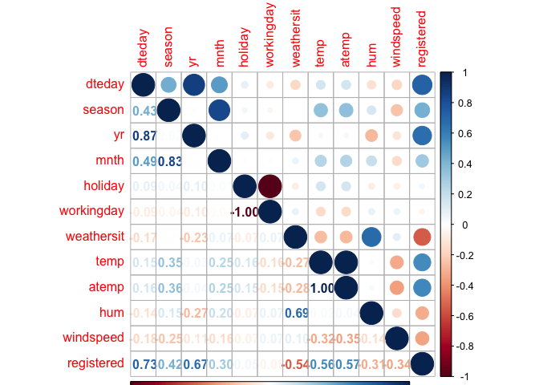

```r
dayNFCor <- cor(as.matrix(dayNF %>%
                            mutate(weekday = fct_recode(weekday, Sunday = "0", Monday = "1", Tuesday = "2", Wednesday = "3", Thursday = "4", Friday = "5", Saturday = "6")) %>%
                            mutate(dteday = as.numeric(dteday)) %>%
                            filter(weekday == params$dayOfWeek) %>%
                            select(2:6, 8:13, registered)))
corrplot(dayNFCor, type = "upper", tl.pos = "lt")
corrplot(dayNFCor, type = "lower", method = "number", add = TRUE, diag = FALSE, tl.pos = "n")
```

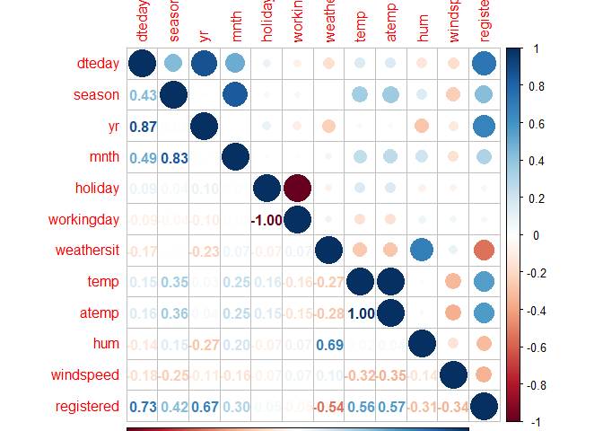

```r
dayNFCor <- cor(as.matrix(dayNF %>%
                            mutate(weekday = fct_recode(weekday, Sunday = "0", Monday = "1", Tuesday = "2", Wednesday = "3", Thursday = "4", Friday = "5", Saturday = "6")) %>%
                            mutate(dteday = as.numeric(dteday)) %>%
                            filter(weekday == params$dayOfWeek) %>%
                            select(2:6, 8:13, registered)))
corrplot(dayNFCor, type = "upper", tl.pos = "lt")
corrplot(dayNFCor, type = "lower", method = "number", add = TRUE, diag = FALSE, tl.pos = "n")
```

First, we remove `workingday`, as it is fully determined by the day of the week and the `holiday` variable, so adds nothing to the model. We also remove `temp`, as it is almost perfectly correlated with `atemp`, and `dteday`, which adds little if any predictive value beyond `yr` plus `mnth` plus `season`.

```r
mlr2 <- update(mlrFull, . ~ . - workingday - temp - dteday)
summary(mlr2)
```

```
##
## Call:
## lm(formula = registered ~ season + yr + mnth + weathersit + atemp +
##     hum + windspeed + holiday, data = dayTrain)
##
## Residuals:
##      Min       1Q   Median       3Q      Max
## -1103.46  -319.98    48.85   325.36  1151.78
##
## Coefficients:
##                           Estimate Std. Error t value Pr(>|t|)
## (Intercept)                 1808.7      699.1   2.587  0.01241 *
## seasonspring                 669.7      383.1   1.748  0.08614 .
## seasonsummer                 802.2      478.5   1.676  0.09945 .
## seasonfall                  1387.5      438.9   3.162  0.00257 **
## yr2012                      1926.4      141.1  13.656  < 2e-16 ***
## mnth2                       -135.7      333.4  -0.407  0.68568
## mnth3                        592.7      378.3   1.567  0.12301
## mnth4                        189.6      553.9   0.342  0.73342
## mnth5                        802.0      550.4   1.457  0.15086
## mnth6                        682.4      592.0   1.153  0.25410
## mnth7                        377.6      661.1   0.571  0.57027
## mnth8                        686.0      641.9   1.069  0.28997
## mnth9                       1012.3      560.8   1.805  0.07662 .
## mnth10                       933.5      592.8   1.575  0.12113
## mnth11                        30.0      513.3   0.058  0.95361
## mnth12                      -116.5      429.2  -0.272  0.78702
## weathersitclear              577.6      202.6   2.851  0.00615 **
## weathersitlightRainOrSnow  -1139.6      342.2  -3.330  0.00157 **
## atemp                       2433.7     1111.2   2.190  0.03285 *
## hum                        -1615.5      778.9  -2.074  0.04285 *
## windspeed                  -1534.7      942.5  -1.628  0.10929
## holiday1                   -1356.2      607.7  -2.232  0.02981 *
## ---
## Signif. codes:  0 '***' 0.001 '**' 0.01 '*' 0.05 '.' 0.1 ' ' 1
##
## Residual standard error: 553.9 on 54 degrees of freedom
## Multiple R-squared:  0.9291, Adjusted R-squared:  0.9015
## F-statistic: 33.68 on 21 and 54 DF,  p-value: < 2.2e-16
```

```r
AIC(mlr2)
```

```
## [1] 1195.887
```

```r
x <- model.matrix(mlr2)[, -1]
e <- eigen(t(x) %*% x)
# e$val
# condition number
kappa <- sqrt(e$val[1]/min(e$val))
```

We see that AIC has changed little, and that

[figure not shown]

= 33.9, which indicates a large reduction in collinearity.

```r
mlr3 <- update(mlr2, . ~ . - mnth)
# summary(mlr3)
AIC(mlr3)
```

```
## [1] 1196.15
```

Remove `weathersit`

```r
mlr4 <- update(mlr2, . ~ . - weathersit)
# summary(mlr4)
AIC(mlr4)
```

```
## [1] 1216.805
```

Remove `windspeed`

```r
mlr5 <- update(mlr2, . ~ . - windspeed)
# summary(mlr5)
AIC(mlr5)
```

```
## [1] 1197.53
```

For `mnth`, `weathersit`, and `windspeed`, removal from the model results in an increase or marginal decrease in AIC. If our main goal were inference and understanding the relationships between the variables, we might want to remove them from the model for the sake of simplicity, interpretability, and more narrow confidence intervals. Because our primary goal here is prediction, we will leave them in the model, and choose mlr2 as our base linear regression model.

We will now do some diagnostic plots on our base model, and then consider adding higher order terms to the model.

We can check for constant variance of our error term, an assumption of our model, by looking at a plot of the model’s fitted values vs the residuals (difference between fitted response and observed response). A “megaphone” shape can indicate non-constant variance.

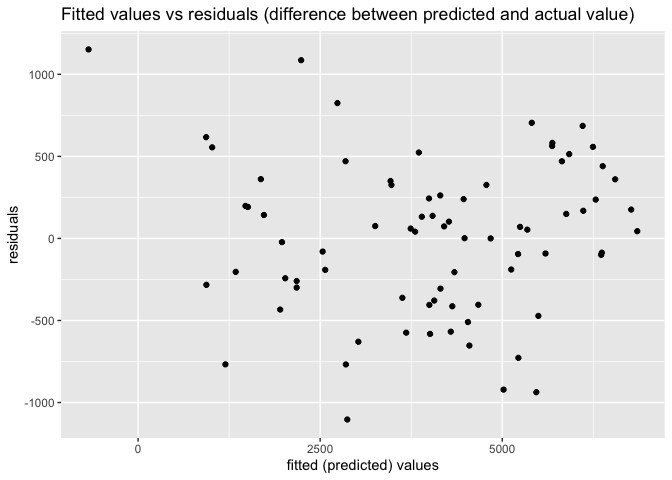

```r
g <- ggplot(mlr2)
g + geom_point(aes(x = .fitted, y = .resid)) + labs (title = "Fitted values vs residuals (difference between predicted and actual value)", x = "fitted (predicted) values", y = "residuals")
```

Another way to assess constant variance is with the Box-Cox method, which can suggest transformations of the response to address problems with non-constant variance. If the maximum log-likelihood of

[figure not shown]

close to 1, as in this case, indicates that non-constant variance is not a problem with the existing model.

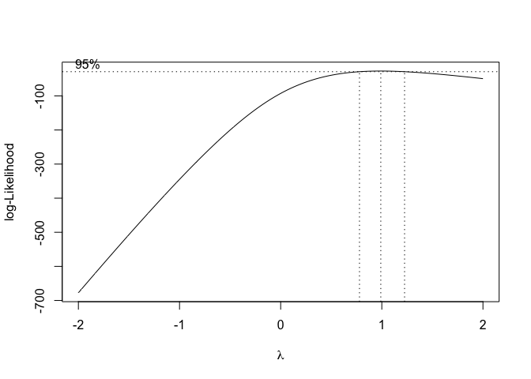

```r
MASS::boxcox(mlr2)
```

We will also look at for signs of nonlinearity, which can indicate the need for quadratic terms for some of the predictors. The partial residual plots below plot the relationship between each predictor and the response, with the effect of the other predictors removed.

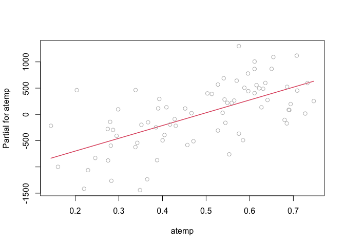

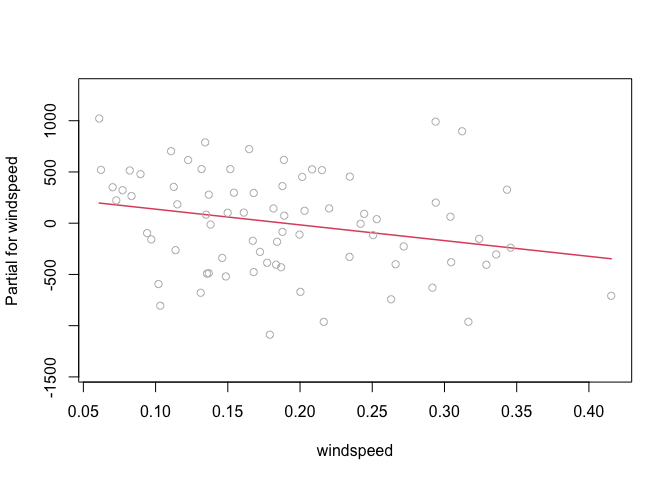

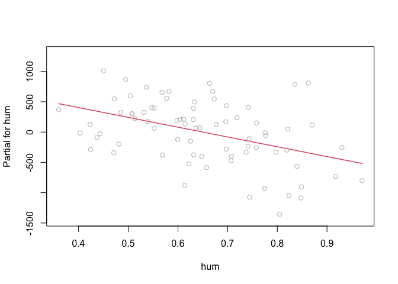

```r
termplot(mlr2, partial.resid = TRUE, terms = c("atemp", "windspeed", "hum"))
```

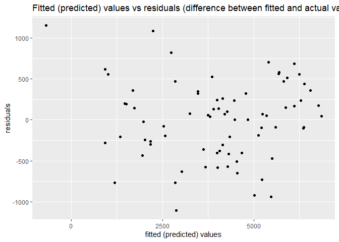

```r
g <- ggplot(mlr2)
g + geom_point(aes(x = .fitted, y = .resid)) + labs (title = "Fitted (predicted) values vs residuals (difference between fitted and actual value)", x = "fitted (predicted) values", y = "residuals")
```

Another way to assess constant variance is with the Box-Cox method, which can suggest transformations of the response to address problems with non-constant variance. If the maximum log-likelihood of *λ* close to 1, as in this case, indicates that non-constant variance is not a problem with the existing model.

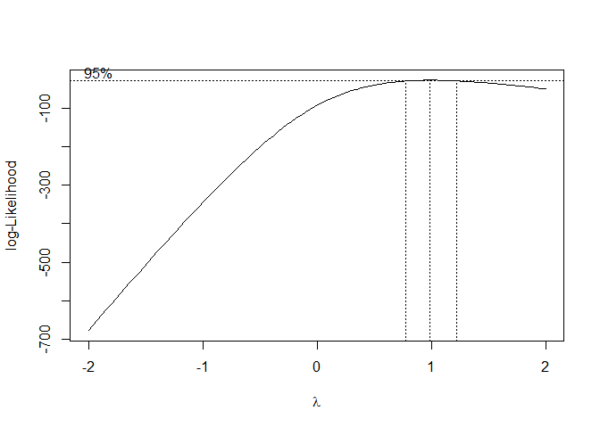

```r
MASS::boxcox(mlr2)
```

We will also look at for signs of nonlinearity, which can indicate the need for quadratic terms for some of the predictors. The partial residual plots below plot the relationship between each predictor and the response, with the effect of the other predictors removed.

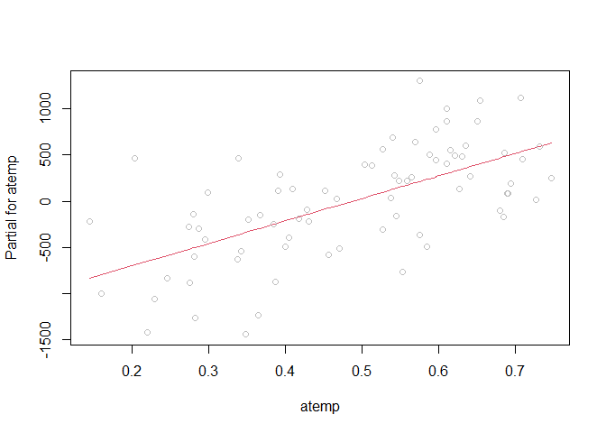

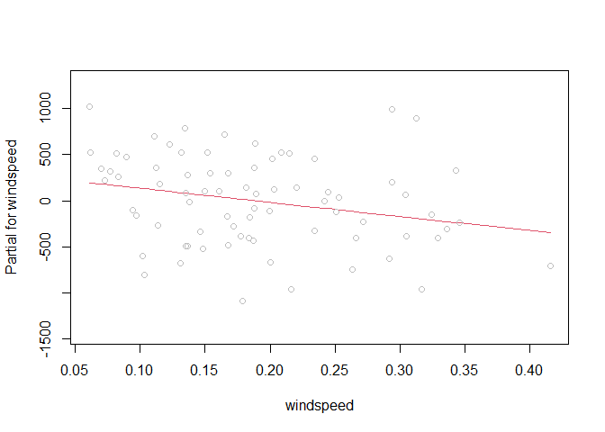

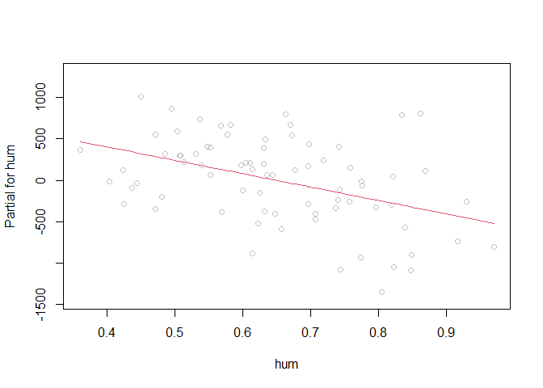

```r
termplot(mlr2, partial.resid = TRUE, terms = c("atemp", "windspeed", "hum"))
```

For at least some days of the week there is a nonlinear pattern to the plots, particularly for `atemp`, so we will try adding quadratic terms for each of them to our base model.

Try adding

[figure not shown]

to base model

```r
mlr8 <- update(mlr2, . ~ . + I(atemp^2))
summary(mlr8)
```

```
##
## Call:
## lm(formula = registered ~ season + yr + mnth + weathersit + atemp +
##     hum + windspeed + holiday + I(atemp^2), data = dayTrain)
##
## Residuals:
##      Min       1Q   Median       3Q      Max
## -1121.62  -332.75    43.36   318.66  1176.71
##
## Coefficients:
##                           Estimate Std. Error t value Pr(>|t|)
## (Intercept)                1608.00     889.29   1.808  0.07625 .
## seasonspring                653.17     388.75   1.680  0.09881 .
## seasonsummer                794.13     482.88   1.645  0.10598
## seasonfall                 1351.73     452.81   2.985  0.00428 **
## yr2012                     1913.16     146.67  13.044  < 2e-16 ***
## mnth2                      -158.49     341.74  -0.464  0.64470
## mnth3                       552.46     396.55   1.393  0.16939
## mnth4                       150.21     568.41   0.264  0.79260
## mnth5                       783.83     557.00   1.407  0.16520
## mnth6                       694.91     597.73   1.163  0.25021
## mnth7                       412.35     673.01   0.613  0.54270
## mnth8                       697.48     647.83   1.077  0.28652
## mnth9                      1009.50     565.34   1.786  0.07988 .
## mnth10                      926.03     597.90   1.549  0.12738
## mnth11                       20.57     518.11   0.040  0.96848
## mnth12                     -126.38     433.53  -0.292  0.77180
## weathersitclear             566.90     206.22   2.749  0.00816 **
## weathersitlightRainOrSnow -1143.89     345.13  -3.314  0.00166 **
## atemp                      3757.65    3749.10   1.002  0.32076
## hum                       -1648.48     790.24  -2.086  0.04180 *
## windspeed                 -1533.33     950.16  -1.614  0.11252
## holiday1                  -1314.64     622.86  -2.111  0.03954 *
## I(atemp^2)                -1483.67    4009.59  -0.370  0.71283
## ---
## Signif. codes:  0 '***' 0.001 '**' 0.01 '*' 0.05 '.' 0.1 ' ' 1
##
## Residual standard error: 558.4 on 53 degrees of freedom
## Multiple R-squared:  0.9293, Adjusted R-squared:  0.8999
## F-statistic: 31.64 on 22 and 53 DF,  p-value: < 2.2e-16
```

```r
AIC(mlr8)
```

```
## [1] 1197.691
```

Reduced or similar AIC, so keep mlr8 as a candidate model to compare using cross validation.

Try adding

[figure not shown]

and

[figure not shown]

to base model

```r
mlr9 <- update(mlr8, . ~ . + I(hum^2))
summary(mlr9)
```

```
##
## Call:
## lm(formula = registered ~ season + yr + mnth + weathersit + atemp +
##     hum + windspeed + holiday + I(atemp^2) + I(hum^2), data = dayTrain)
##
## Residuals:
##      Min       1Q   Median       3Q      Max
## -1053.25  -333.08    35.87   335.10  1227.16
##
## Coefficients:
##                            Estimate Std. Error t value Pr(>|t|)
## (Intercept)               -1068.847   1911.834  -0.559  0.57851
## seasonspring                703.625    384.756   1.829  0.07317 .
## seasonsummer                990.681    492.325   2.012  0.04939 *
## seasonfall                 1536.504    461.743   3.328  0.00161 **
## yr2012                     1844.916    150.999  12.218  < 2e-16 ***
## mnth2                      -171.927    337.162  -0.510  0.61226
## mnth3                       506.493    392.203   1.291  0.20227
## mnth4                         3.436    568.303   0.006  0.99520
## mnth5                       670.840    554.027   1.211  0.23143
## mnth6                       555.528    596.135   0.932  0.35570
## mnth7                       196.770    677.741   0.290  0.77272
## mnth8                       383.906    669.228   0.574  0.56867
## mnth9                       751.107    581.210   1.292  0.20196
## mnth10                      583.796    628.434   0.929  0.35720
## mnth11                     -257.562    540.634  -0.476  0.63578
## mnth12                     -343.800    449.301  -0.765  0.44762
## weathersitclear             477.640    211.138   2.262  0.02789 *
## weathersitlightRainOrSnow  -711.788    437.115  -1.628  0.10949
## atemp                      5352.365   3833.715   1.396  0.16861
## hum                        6728.887   5373.217   1.252  0.21606
## windspeed                 -1407.847    940.515  -1.497  0.14047
## holiday1                  -1311.562    614.327  -2.135  0.03750 *
## I(atemp^2)                -3087.557   4083.533  -0.756  0.45300
## I(hum^2)                  -6847.922   4345.782  -1.576  0.12115
## ---
## Signif. codes:  0 '***' 0.001 '**' 0.01 '*' 0.05 '.' 0.1 ' ' 1
##
## Residual standard error: 550.7 on 52 degrees of freedom
## Multiple R-squared:  0.9325, Adjusted R-squared:  0.9026
## F-statistic: 31.22 on 23 and 52 DF,  p-value: < 2.2e-16
```

```r
AIC(mlr9)
```

```
## [1] 1196.146
```

Similar AIC for most days of week, so keep mlr9 as a candidate model to compare using cross validation.

Try adding

[figure not shown]

and

[figure not shown]

to base model

```r
mlr10 <- update(mlr8, . ~ . + I(windspeed^2))
summary(mlr10)
```

```
##
## Call:
## lm(formula = registered ~ season + yr + mnth + weathersit + atemp +
##     hum + windspeed + holiday + I(atemp^2) + I(windspeed^2),
##     data = dayTrain)
##
## Residuals:
##      Min       1Q   Median       3Q      Max
## -1108.55  -376.25    33.38   283.73  1180.16
##
## Coefficients:
##                            Estimate Std. Error t value Pr(>|t|)
## (Intercept)                1834.485    977.196   1.877  0.06609 .
## seasonspring                643.886    391.549   1.644  0.10611
## seasonsummer                813.531    487.108   1.670  0.10090
## seasonfall                 1368.904    456.658   2.998  0.00416 **
## yr2012                     1904.068    148.435  12.828  < 2e-16 ***
## mnth2                      -113.258    352.728  -0.321  0.74943
## mnth3                       579.287    401.769   1.442  0.15534
## mnth4                       198.730    578.164   0.344  0.73244
## mnth5                       820.592    564.146   1.455  0.15180
## mnth6                       707.447    601.917   1.175  0.24522
## mnth7                       422.458    677.514   0.624  0.53565
## mnth8                       683.200    652.419   1.047  0.29986
## mnth9                      1029.217    569.960   1.806  0.07674 .
## mnth10                      936.701    601.986   1.556  0.12577
## mnth11                        1.303    522.468   0.002  0.99802
## mnth12                     -131.337    436.370  -0.301  0.76463
## weathersitclear             564.406    207.578   2.719  0.00888 **
## weathersitlightRainOrSnow -1144.979    347.329  -3.297  0.00177 **
## atemp                      3544.529   3790.944   0.935  0.35411
## hum                       -1639.617    795.411  -2.061  0.04429 *
## windspeed                 -3849.794   4126.159  -0.933  0.35512
## holiday1                  -1323.324    626.996  -2.111  0.03964 *
## I(atemp^2)                -1246.093   4056.007  -0.307  0.75990
## I(windspeed^2)             5532.849   9586.992   0.577  0.56635
## ---
## Signif. codes:  0 '***' 0.001 '**' 0.01 '*' 0.05 '.' 0.1 ' ' 1
##
## Residual standard error: 561.9 on 52 degrees of freedom
## Multiple R-squared:  0.9297, Adjusted R-squared:  0.8986
## F-statistic:  29.9 on 23 and 52 DF,  p-value: < 2.2e-16
```

```r
AIC(mlr10)
```

```
## [1] 1199.206
```

Similar AIC for most days of week, so keep mlr10 as a candidate model to compare using cross validation.

Try including all 3 quadratic terms

```r
mlr11 <- update(mlr8, . ~ . + I(hum^2) + I(windspeed^2))
summary(mlr11)
```

```
##
## Call:
## lm(formula = registered ~ season + yr + mnth + weathersit + atemp +
##     hum + windspeed + holiday + I(atemp^2) + I(hum^2) + I(windspeed^2),
##     data = dayTrain)
##
## Residuals:
##      Min       1Q   Median       3Q      Max
## -1041.62  -398.22    35.82   303.12  1183.79
##
## Coefficients:
##                           Estimate Std. Error t value Pr(>|t|)
## (Intercept)                -834.17    1972.14  -0.423  0.67409
## seasonspring                694.51     387.73   1.791  0.07920 .
## seasonsummer               1007.14     496.59   2.028  0.04779 *
## seasonfall                 1550.98     465.64   3.331  0.00162 **
## yr2012                     1837.00     152.71  12.029  < 2e-16 ***
## mnth2                      -129.52     348.21  -0.372  0.71147
## mnth3                       531.97     397.62   1.338  0.18686
## mnth4                        50.06     578.49   0.087  0.93138
## mnth5                       706.18     561.53   1.258  0.21427
## mnth6                       568.44     600.66   0.946  0.34843
## mnth7                       208.07     682.67   0.305  0.76177
## mnth8                       373.24     674.07   0.554  0.58220
## mnth9                       771.75     586.39   1.316  0.19402
## mnth10                      596.70     633.15   0.942  0.35042
## mnth11                     -273.20     545.07  -0.501  0.61837
## mnth12                     -346.57     452.39  -0.766  0.44715
## weathersitclear             476.07     212.59   2.239  0.02952 *
## weathersitlightRainOrSnow  -716.50     440.18  -1.628  0.10974
## atemp                      5139.45    3879.42   1.325  0.19114
## hum                        6665.47    5411.05   1.232  0.22366
## windspeed                 -3574.85    4075.33  -0.877  0.38450
## holiday1                  -1319.71     618.69  -2.133  0.03775 *
## I(atemp^2)                -2851.69    4133.92  -0.690  0.49343
## I(hum^2)                  -6789.31    4376.69  -1.551  0.12703
## I(windspeed^2)             5173.28    9462.76   0.547  0.58697
## ---
## Signif. codes:  0 '***' 0.001 '**' 0.01 '*' 0.05 '.' 0.1 ' ' 1
##
## Residual standard error: 554.5 on 51 degrees of freedom
## Multiple R-squared:  0.9329, Adjusted R-squared:  0.9013
## F-statistic: 29.53 on 24 and 51 DF,  p-value: < 2.2e-16
```

```r
AIC(mlr11)
```

```
## [1] 1197.702
```

Similar AIC for most days of week, so keep mlr11 as a candidate model to compare using cross validation.

We will now compare the 4 candidate models using cross validation. Several measures of the performance of the model are returned. We will choose the best model in terms of lowest Root Mean Squared Error.

```r
if(length(unique(dayTrain$holiday)) != 1){
  mlrFit8 <- train(registered ~ season + yr + mnth + holiday + weathersit + atemp + hum + windspeed + I(atemp^2), data = dayTrain,
      method = "lm",
      preProcess = c("center", "scale"),
      trControl = trainControl(method = "repeatedcv", number = 4, repeats = 3))

  mlrFit9 <- train(registered ~ season + yr + mnth + holiday + weathersit + atemp + hum + windspeed + I(atemp^2) + I(hum^2), data = dayTrain,
      method = "lm",
      preProcess = c("center", "scale"),
      trControl = trainControl(method = "repeatedcv", number = 4, repeats = 3))

  mlrFit10 <- train(registered ~ season + yr + mnth + holiday + weathersit + atemp + hum + windspeed + I(atemp^2) + I(windspeed^2), data = dayTrain,
      method = "lm",
      preProcess = c("center", "scale"),
      trControl = trainControl(method = "repeatedcv", number = 4, repeats = 3))

  mlrFit11 <- train(registered ~ season + yr + mnth + holiday + weathersit + atemp + hum + windspeed + I(atemp^2) + I(hum^2)+ I(windspeed^2), data = dayTrain,
      method = "lm",
      preProcess = c("center", "scale"),
      trControl = trainControl(method = "repeatedcv", number = 4, repeats = 3))
}else{
  mlrFit8 <- train(registered ~ season + yr + mnth + weathersit + atemp + hum + windspeed + I(atemp^2), data = dayTrain,
      method = "lm",
      preProcess = c("center", "scale"),
      trControl = trainControl(method = "repeatedcv", number = 4, repeats = 3))

  mlrFit9 <- train(registered ~ season + yr + mnth + weathersit + atemp + hum + windspeed + I(atemp^2) + I(hum^2), data = dayTrain,
      method = "lm",
      preProcess = c("center", "scale"),
      trControl = trainControl(method = "repeatedcv", number = 4, repeats = 3))

  mlrFit10 <- train(registered ~ season + yr + mnth + weathersit + atemp + hum + windspeed + I(atemp^2) + I(windspeed^2), data = dayTrain,
      method = "lm",
      preProcess = c("center", "scale"),
      trControl = trainControl(method = "repeatedcv", number = 4, repeats = 3))

  mlrFit11 <- train(registered ~ season + yr + mnth + weathersit + atemp + hum + windspeed + I(atemp^2) + I(hum^2)+ I(windspeed^2), data = dayTrain,
      method = "lm",
      preProcess = c("center", "scale"),
      trControl = trainControl(method = "repeatedcv", number = 4, repeats = 3))
}
comparison <- data.frame(t(mlrFit8$results), t(mlrFit9$results), t(mlrFit10$results), t(mlrFit11$results))
colnames(comparison) <- c("mlrFit8", "mlrFit9", "mlrFit10", "mlrFit11")
kable(comparison)
```

|  | mlrFit8 | mlrFit9 | mlrFit10 | mlrFit11 |
| --- | --- | --- | --- | --- |
| intercept | 1.0000000 | 1.0000000 | 1.0000000 | 1.0000000 |
| RMSE | 746.1617485 | 764.4939506 | 786.1903494 | 805.5999131 |
| Rsquared | 0.8514152 | 0.8617486 | 0.8394608 | 0.8345011 |
| MAE | 588.2234534 | 610.6631470 | 630.7843075 | 633.6790867 |
| RMSESD | 95.2500400 | 162.1670687 | 132.8154993 | 132.7447578 |
| RsquaredSD | 0.0344218 | 0.0390126 | 0.0569581 | 0.0572919 |
| MAESD | 66.3353255 | 116.5578468 | 107.5472096 | 110.9026838 |

Save the model with the lowest RMSE as our second linear regression model.

```r
candidates <- list(mlrFit8 = mlrFit8, mlrFit9 = mlrFit9, mlrFit10 = mlrFit10, mlrFit11 = mlrFit11)
indexLowestRMSE <- which.min(c(candidates[[1]][["results"]]["RMSE"], candidates[[2]][["results"]]["RMSE"], candidates[[3]][["results"]]["RMSE"], candidates[[4]][["results"]]["RMSE"]))
mlrFinal2 <- candidates[[indexLowestRMSE]]
mlrFinal2$call[[2]]
```

```
## registered ~ season + yr + mnth + holiday + weathersit + atemp +
##     hum + windspeed + I(atemp^2)
```

### Random Forest Model

The random forest model is an improvement on the bagged tree model, which is an improvement on the basic decision tree model. Decision trees make predictions by dividing the predictor space into a number of regions, and determining which region the predictor values of the new observation fall into by applying a series of splits, each based on the value of a single predictor. The response for the new observation is then predicted to be the mean of the responses of the observations in that region (for regression models; for classification models, the prediction is the predominant class observed in the region). First a large tree is grown, with the goal of minimizing the residual sum of squares, resulting in a tree with many regions, each containing a small number of observations. But this complex tree will generally be overfit, with low bias and high variance, so it gets pruned back to an optimal size, determined by cross validation, that will have higher bias but lower variance, and ideally perform better when predicting on new data.

Bagged tree models improve on basic decision trees by using the bootstrap to take many samples from the training data set and producing an unpruned tree from each sample, then averaging the predictions of those trees to get the bagged tree model. The averaging of hundreds of high-variance trees results in a much lower variance model.

The random forest model is a further improvement on the bagged tree, which works by decorrelating the trees that are generated and averaged together. In a bagged tree model, many of the trees can end up being similar, with the main splits dominated by the strongest predictor(s). The correlation between these trees means that averaging them results in a smaller reduction in variance than desired. To remedy this, random forest models consider only a random subset of predictors for each split, resulting in less correlation between trees, and lower variance in the final model. The number of predictors considered for each split is a tuning parameter, whose value can be chosen using cross validation. …

```r
rfFit <- train(registered ~ . - instant - casual - cnt, data = dayTrain,
               method = "rf",
               trControl = trainControl(method = "repeatedcv", number = 4, repeats = 3),
               preProcess = c("center", "scale"),
               tuneGrid = expand.grid(mtry = c(2, 7, 10:16, 20, 24)))
rfFit
```

```
## Random Forest
##
## 76 samples
## 15 predictors
##
## Pre-processing: centered (30), scaled (30)
## Resampling: Cross-Validated (4 fold, repeated 3 times)
## Summary of sample sizes: 57, 58, 56, 57, 57, 57, ...
## Resampling results across tuning parameters:
##
##   mtry  RMSE       Rsquared   MAE
##    2    1076.7243  0.8557197  890.8661
##    7     738.7018  0.8612492  573.2194
##   10     739.0018  0.8501349  553.9870
##   11     739.4557  0.8444490  547.4586
##   12     746.7602  0.8390557  547.0814
##   13     750.0277  0.8368340  549.5310
##   14     759.7321  0.8307481  550.3715
##   15     760.5277  0.8286920  553.3443
##   16     764.4022  0.8233636  551.6432
##   20     786.8087  0.8093484  561.5521
##   24     803.2911  0.7994283  576.2451
##
## RMSE was used to select the optimal model using the smallest value.
## The final value used for the model was mtry = 7.
```

### Boosted Regression Tree

A boosted regression tree is similar to other tree-based regression models, in that the regression is based on decision trees. Like other decision-tree models, random samples are taken to build iterations of the tree, but what makes boosted trees unique is that each iteration attempts to build and improve on the last version and predictions are updated as the trees are grown.

The predictions are initialized to 0 and residuals are created. A tree is then fit to those residuals as a response. The predictions are then updated again, the response becomes the new residuals, and the process continues until a pre-determined number of **B** times has been reached.

There are four parameters that can be chosen using cross-validation to create the best fit:

- the shrinkage parameter: also known as the learning rate, this parameter determines how quickly the model learns. This parameter is between 0 and 1, and when tuning, 0.1 is usually a good place to start.
- number of trees: this can lead to over-fitting if the number of trees is too large.
- interaction depth: an interaction depth of 1 would be an additive model, while 2 would have two-way interactions. It is generally recommended to look at a interaction depth of something near 2 to 8.
- min observations per node: default is 10, but this number can be dropped especially if data is sparse.

```r
n.trees <- seq(5, 100, 5)
int.depth <- 1:10
shrinkage <- seq(0.05, 0.2, 0.05)
minobs <- seq(2, 12, 2)
grid <- expand.grid(n.trees = n.trees,
                    interaction.depth = int.depth,
                    shrinkage = shrinkage,
                    n.minobsinnode = minobs)

trControl <- trainControl(method='repeatedcv', number=4, repeats=10)
set.seed(1)
fit_boost <- train(registered ~ .,
                   data=dayTrain %>%
                        drop_na() %>%
                        select(-instant, -casual, -cnt),
                   method='gbm',
                   tuneGrid = grid,
                   trControl=trControl,
                   verbose=FALSE)
```

# Comparison of models

We will now compare the performance of the two linear regression models, the random forest model, and the boosted tree model, by using each to predict the `registered` response based on the values of the predictor variables in the test data set that we partitioned at the beginning. We will choose the best model on the basis of lowest Root Mean Squared Error.

```r
final4 <- list(first_linear_regression = lm.fit1, second_linear_regression = mlrFinal2, random_forest = rfFit, boosted_tree = fit_boost)
rmse <- numeric()
results <- list()
predFinal4 <- predict(final4, newdata = dayTest)
for(i in 1:length(final4)){
  results[[i]] <- postResample(predFinal4[[i]], dayTest$registered)
  rmse[i] <- postResample(predFinal4[[i]], dayTest$registered)["RMSE"]
}
resultsComparison <- data.frame(results)
colnames(resultsComparison) <- names(final4)
kable(t(resultsComparison), digits = 3)
```

|  | RMSE | Rsquared | MAE |
| --- | --- | --- | --- |
| first_linear_regression | 497.908 | 0.912 | 372.159 |
| second_linear_regression | 578.242 | 0.881 | 438.079 |
| random_forest | 550.781 | 0.897 | 457.463 |
| boosted_tree | 496.436 | 0.905 | 411.632 |

```r
winnerIndex <- which.min(rmse)
```

The best-performing model for Wednesday is boosted_tree